# Lab 11x

## 4. Networks

### Load Package and Example Data

```r
#library(phyloseq); packageVersion("phyloseq")
#library("ggplot2"); packageVersion("ggplot2")
data(enterotype)
```

There is a random aspect to some of the network layout methods. For complete reproducibility of the images produced later in this tutorial, it is possible to set the random number generator seed explicitly:

```r
set.seed(711L)
```

Because we want to use the enterotype designations as a plot feature in these plots, we need to remove the 9 samples for which no enterotype designation was assigned.

```r
enterotype = subset_samples(enterotype, !is.na(Enterotype))
```

### The plot_net function

Try plot_net with the default settings.

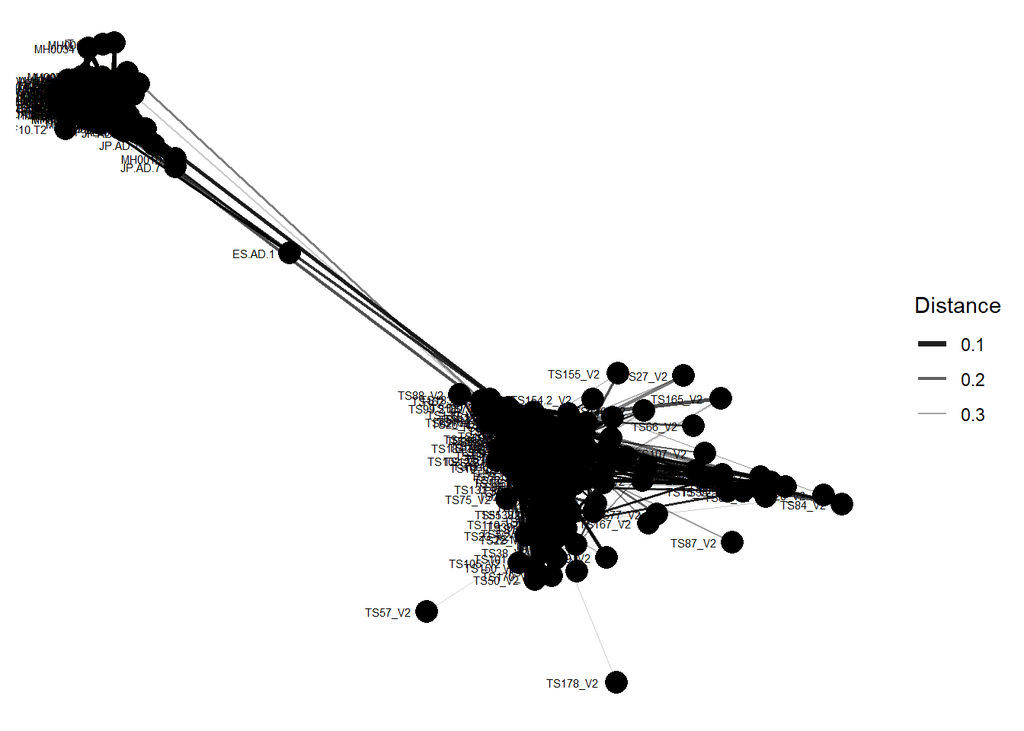

```r
plot_net(enterotype, maxdist = 0.4, point_label = "Sample_ID")
```

Instead of trying to read all of the sample names to understand the pattern, let’s map some of the sample variables onto this graphic as color and shape:

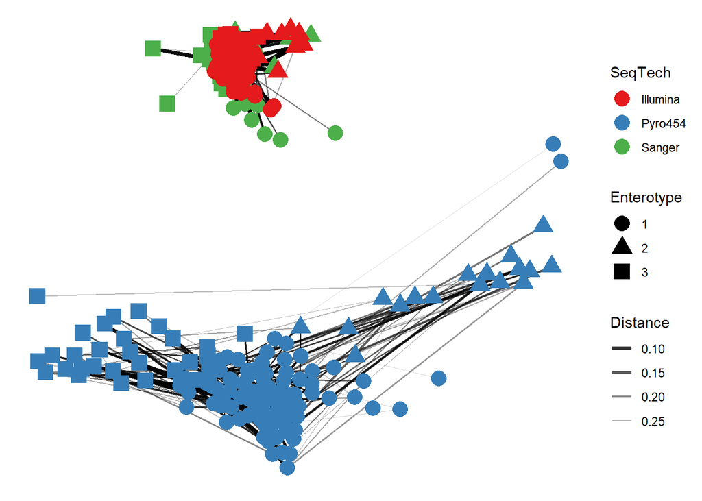

```r
plot_net(enterotype, maxdist = 0.3, color = "SeqTech", shape="Enterotype")
```

### The plot_network function

Create an igraph-based network based on the default distance method, “Jaccard”, and a maximum distance between connected nodes of 0.3.

```r
ig <- make_network(enterotype, max.dist=0.3)
```

Now plot this network representation with the default settings.

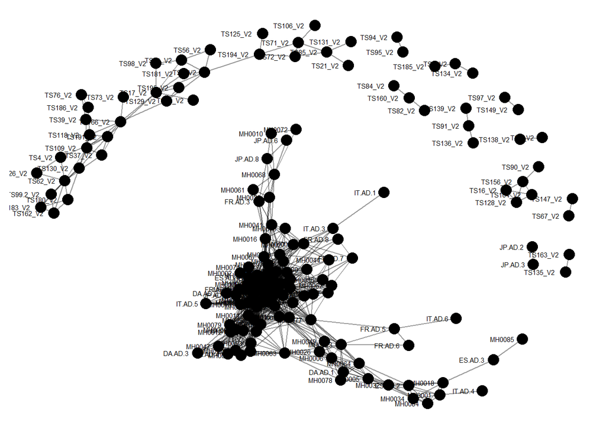

```r
plot_network(ig, enterotype)
```

Instead of trying to read all of the sample names to understand the pattern, let’s map some of the sample variables onto this graphic as color and shape:

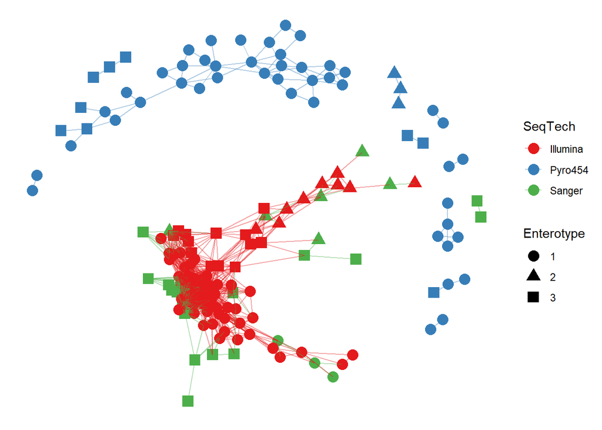

```r
plot_network(ig, enterotype, color="SeqTech", shape="Enterotype", line_weight=0.4, label=NULL)
```

In the previous examples, the choice of maximum-distance and distance method were informed, but arbitrary. Let’s see what happens when the maximum distance is lowered, decreasing the number of edges in the network.

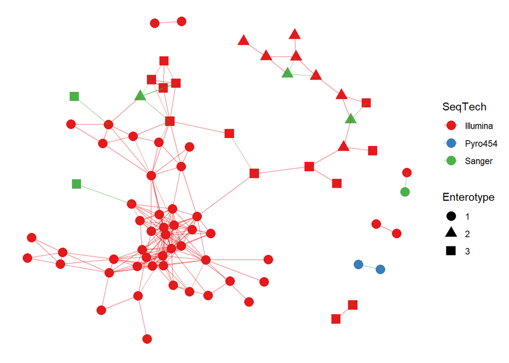

```r
ig <- make_network(enterotype, max.dist=0.2)
plot_network(ig, enterotype, color="SeqTech", shape="Enterotype", line_weight=0.4, label=NULL)
```

Let’s repeat the previous exercise, but replace the Jaccard (default) distance method with Bray-Curtis

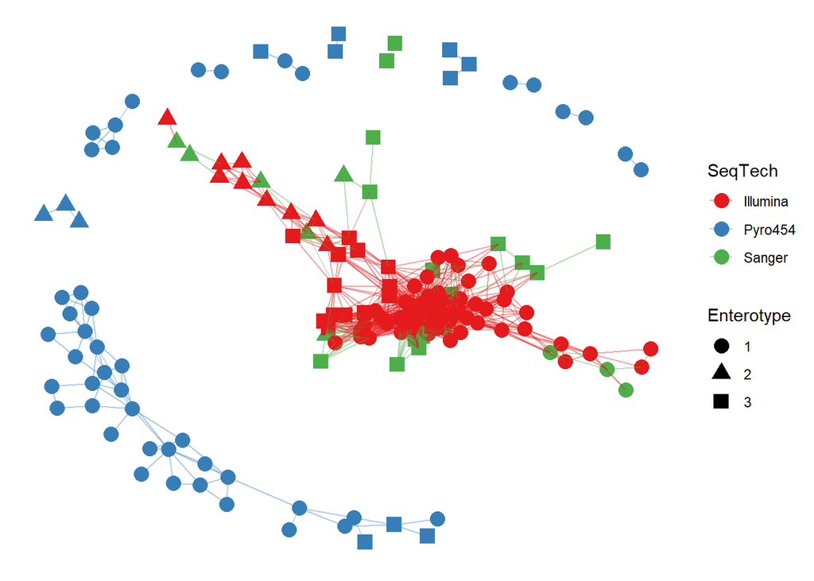

```r
ig <- make_network(enterotype, dist.fun="bray", max.dist=0.3)
plot_network(ig, enterotype, color="SeqTech", shape="Enterotype", line_weight=0.4, label=NULL)
```